# R Notebook

```r
rownames(data.abiotic)
```

```
   [1] "STMDF90" "STMCJ24" "STMJH42" "STMDE66" "STMIX74" "STMCL34" "STMHZ45" "STMCC46"
   [9] "STMIZ34" "STMGU22" "STMJB83" "STMGL58" "STMIF71" "STMEG62" "STMIA38" "STMEN69"
  [17] "STMIU07" "STMIO15" "STMJF27" "STMIB60" "STMCV88" "STMII07" "STMGS47" "STMDU49"
  [25] "STMFB37" "STMEP44" "STMDO65" "STMEQ29" "STMCE83" "STMJJ55" "STMGS80" "STMDW06"
  [33] "STMGA57" "STMII23" "STMEL85" "STMEG74" "STMEY42" "STMCO26" "STMIR13" "STMCL31"
  [41] "STMDP93" "STMGU57" "STMGR66" "STMGG63" "STMHX33" "STMIY34" "STMID05" "STMJG15"
  [49] "STMEV78" "STMGY71" "STMGT13" "STMIL64" "STMDV94" "STMHK85" "STMCB92" "STMEM10"
  [57] "STMCR77" "STMHQ28" "STMCA77" "STMGM84" "STMDS75" "STMDV87" "STMID12" "STMGO09"
  [65] "STMCV66" "STMDD69" "STMDB28" "STMHI80" "STMDH27" "STMGE42" "STMGP38" "STMGH56"
  [73] "STMCC74" "STMEJ16" "STMIP56" "STMCO67" "STMCD46" "STMCA59" "STMGO65" "STMIT95"
  [81] "STMGN09" "STMIX77" "STMJE19" "STMET15" "STMIQ53" "STMGC02" "STMEA13" "STMGO06"
  [89] "STMDV92" "STMET69" "STMHJ39" "STMJA27" "STMGU26" "STMJH69" "STMEY32" "STMBB20"
  [97] "STMGB57" "STMIT31" "STMEI33" "STMEZ42" "STMEP33" "STMIZ88" "STMCV36" "STMDP18"
 [105] "STMIM44" "STMET73" "STMCM65" "STMHN16" "STMCX23" "STMCZ93" "STMGB24" "STMEY09"
 [113] "STMCZ42" "STMGN63" "STMFB58" "STMCX26" "STMCO46" "STMCE01" "STMIX35" "STMET12"
```

[output cut: 110 more lines]

3.1 Defining the regression model

```r
design <- make.design.matrix(edesign.abiotic, degree = 2)
#This example has three time points, so we can consider up to a quadratic regression model
#(degree = 2)
# ...matrix(data table , quadratic and etc)

# show design
design
```

```
$dis
              ColdvsControl HeatvsControl SaltvsControl Time TimexCold TimexHeat TimexSalt
Control_3H_1              0             0             0    3         0         0         0
Control_3H_2              0             0             0    3         0         0         0
Control_3H_3              0             0             0    3         0         0         0
Control_9H_1              0             0             0    9         0         0         0
Control_9H_2              0             0             0    9         0         0         0
Control_9H_3              0             0             0    9         0         0         0
Control_27H_1             0             0             0   27         0         0         0
Control_27H_2             0             0             0   27         0         0         0
Control_27H_3             0             0             0   27         0         0         0
Cold_3H_1                 1             0             0    3         3         0         0
Cold_3H_2                 1             0             0    3         3         0         0
Cold_3H_3                 1             0             0    3         3         0         0
Cold_9H_1                 1             0             0    9         9         0         0
Cold_9H_2                 1             0             0    9         9         0         0
Cold_9H_3                 1             0             0    9         9         0         0
Cold_27H_1                1             0             0   27        27         0         0
Cold_27H_2                1             0             0   27        27         0         0
Cold_27H_3                1             0             0   27        27         0         0
Heat_3H_1                 0             1             0    3         0         3         0
Heat_3H_2                 0             1             0    3         0         3         0
Heat_3H_3                 0             1             0    3         0         3         0
Heat_9H_1                 0             1             0    9         0         9         0
Heat_9H_2                 0             1             0    9         0         9         0
Heat_9H_3                 0             1             0    9         0         9         0
Heat_27H_1                0             1             0   27         0        27         0
Heat_27H_2                0             1             0   27         0        27         0
Heat_27H_3                0             1             0   27         0        27         0
Salt_3H_1                 0             0             1    3         0         0         3
Salt_3H_2                 0             0             1    3         0         0         3
Salt_3H_3                 0             0             1    3         0         0         3
Salt_9H_1                 0             0             1    9         0         0         9
Salt_9H_2                 0             0             1    9         0         0         9
Salt_9H_3                 0             0             1    9         0         0         9
Salt_27H_1                0             0             1   27         0         0        27
Salt_27H_2                0             0             1   27         0         0        27
Salt_27H_3                0             0             1   27         0         0        27
              Time2 Time2xCold Time2xHeat Time2xSalt
Control_3H_1      9          0          0          0
```

[output cut: 64 more lines]

```
Heat_9H_1        9         8       0    0    1    0
Heat_9H_2        9         8       0    0    1    0
Heat_9H_3        9         8       0    0    1    0
Heat_27H_1      27         9       0    0    1    0
Heat_27H_2      27         9       0    0    1    0
Heat_27H_3      27         9       0    0    1    0
Salt_3H_1        3        10       0    0    0    1
Salt_3H_2        3        10       0    0    0    1
Salt_3H_3        3        10       0    0    0    1
Salt_9H_1        9        11       0    0    0    1
Salt_9H_2        9        11       0    0    0    1
Salt_9H_3        9        11       0    0    0    1
Salt_27H_1      27        12       0    0    0    1
Salt_27H_2      27        12       0    0    0    1
Salt_27H_3      27        12       0    0    0    1
```

```r
design$groups.vector # contains the assignment of regression variables to experimental groups.
```

```
 [1] "ColdvsControl" "HeatvsControl" "SaltvsControl" "Control"       "ColdvsControl"
 [6] "HeatvsControl" "SaltvsControl" "Control"       "ColdvsControl" "HeatvsControl"
[11] "SaltvsControl"
```

3.2 Finding significant genes

```r
# do a regression fit
 fit <- p.vector(data.abiotic, design, Q = 0.05, MT.adjust = "BH", min.obs = 20)
```

```
[1] "fitting  gene 100 out of 878"
[1] "fitting  gene 200 out of 878"
[1] "fitting  gene 300 out of 878"
[1] "fitting  gene 400 out of 878"
[1] "fitting  gene 500 out of 878"
[1] "fitting  gene 600 out of 878"
[1] "fitting  gene 700 out of 878"
[1] "fitting  gene 800 out of 878"
```

```r
 # the data you want to process
#     design matrix for the regression fit such as that generated by themake.design.matrix function
#                                  Q --> significance level

# MT.adjust ---> use BH meathod
# min.obs --> genes with less than this number of true numerical values will be excluded from the analysis. Minimum value to estimate the model is (degree+1)xGroups+1. Default is 6.



#   performs a regression fit for each gene taking all variables present in the model given by a regression matrix and returns a list of FDR corrected significant genes.



fit$i # returns the number of significant genes
```

```
[1] 398
```

```r
fit$alfa # gives p-value at the Q false discovery control level
```

[output not shown]

```r
fit$SELEC # is a matrix with the significant genes and their expression values
```

```
        Control_3H_1 Control_3H_2 Control_3H_3 Control_9H_1 Control_9H_2 Control_9H_3
STMDF90  0.137357139 -0.365306508 -0.153294481  0.447545350  0.287476796  0.248818724
STMJH42  0.078644494  0.100232848 -0.173654882 -0.252794839  0.184855409 -0.118319967
STMDE66  0.229769912  0.474097484  0.469307162  0.371010592 -0.004992029  0.002459839
STMIX74  0.144076178 -0.480186374 -0.078479988  0.056923312  0.013045420  0.076794351
STMCL34  0.064940783  0.044729856  0.042807898  0.161280907  0.088048892  0.277007348
STMHZ45 -0.002160594  0.244904772  0.425135293  0.112474729  0.066246355  0.050596642
STMCC46  0.129241254  0.087195779  0.028374645  0.344013558 -0.078126780  0.070784100
STMGU22  0.144490418  0.167739140  0.345003852 -0.128139859  0.044096237  0.139976009
STMGL58  0.056722590 -0.020265848  0.085521960           NA  0.062735755  0.142740172
STMIF71  0.092409311 -0.278561218 -0.244468698 -0.146866262 -0.145297618 -0.174628058
STMEG62 -0.138563446 -0.033454129  0.246808446  0.043602781  0.331018711  0.451136587
STMIA38  0.149447810  0.466600630  0.192727478 -0.190228907 -0.309200664 -0.377035292
STMII07 -0.344651637 -0.379898164 -0.391336937 -0.648402719 -0.532210609 -0.804019880
STMGS47  0.106187456  0.133266531  0.065222447 -0.256078021  0.152655749  0.181053568
STMFB37  0.020346037 -0.131397889  0.070970427  0.412806642 -0.079829024  0.270772732
STMDO65           NA  0.265111721  0.966833136  0.345891338  0.150097771  0.771854051
STMEQ29  0.070684992  0.000000000 -0.114986329  0.473279192  0.328749765  0.102886606
STMDW06 -0.005101334  0.129628531 -0.000796409  0.111586836  0.069217043  0.195483096
STMEL85 -0.055115958 -0.058403072 -0.109196819  0.400965477  0.118580232  0.352481727
STMEG74 -0.267950474 -0.212879562 -0.193853411  0.186332758 -0.032933889  0.018929729
STMCO26 -0.008634610 -0.401341510 -0.293583469  0.116368645 -0.157091553 -0.083132458
STMGU57  0.066671040  0.226512577  0.306798570 -0.113506222 -0.011448204  0.235234874
STMHX33 -0.085333933  0.052962766  0.219280590  0.006551335 -0.258831260  0.051074185
STMID05  0.057727528  0.011479008 -0.200628849 -0.459188270 -0.169340153 -0.418032863
STMEV78  0.289735091 -0.008042297 -0.068183572 -0.048730016 -0.108219866 -0.038247469
STMGY71 -0.110428618 -0.412550808 -0.286413565  0.069880023 -0.108961809  0.216588029
STMDV94 -0.085406642  0.080498749 -0.258469372 -0.247899212 -0.281946973 -0.388109820
        Control_27H_1 Control_27H_2 Control_27H_3    Cold_3H_1    Cold_3H_2    Cold_3H_3
STMDF90   0.179325865   0.127993099  -0.117346844  1.056555447  0.394892104  0.388420263
STMJH42  -0.148218361  -0.091147888  -0.271326183 -0.169700160  0.365709787  0.524496826
STMDE66  -0.003879953   0.261827635   0.294490316 -1.908442715 -0.826778295 -0.118538332
STMIX74  -0.128584206   0.193453537   0.109400918  0.268683853 -0.026057813  0.067665976
STMCL34   0.046143427   0.162755905   0.056277869 -0.052391198  0.010102404  0.252152933
STMHZ45  -0.138750990  -0.035146275   0.429953961  1.515001811  1.495604301  1.478097763
STMCC46  -0.128954603   0.254174429  -0.079143885 -0.209592450 -0.205448108 -0.216072825
STMGU22   0.176658108   0.050983929   0.197361778 -0.519153702 -0.165922620  0.006960562
STMGL58  -0.091833066  -0.051208249   0.045193423           NA  0.530803313  0.314734482
STMIF71   0.043878199  -0.172731362   0.048577372  0.473790649  0.329715208  0.253864901
STMEG62   0.078018024   0.040223013   0.175026004  0.697838148  0.180232897  0.310481991
```

[output cut: 114 more lines]

```
STMGS47 -0.145167260 -0.287067096 -0.337849494 -0.252859185 -0.393131815 -0.073727613
STMFB37  0.289711147  0.209045729  0.186626969  0.154697750  0.275917892 -0.127950607
STMDO65  1.204057686  1.162782932  0.878416302  1.164949406  0.735543519  0.807354922
STMEQ29  0.598555702  1.228816207  1.241632619  0.887055997  0.852552310  1.586146954
STMDW06  0.010910486 -0.121336769 -0.054714259  0.008211999 -0.137074852 -0.324331538
STMEL85  0.552599550  0.211855156  0.068615415 -0.010234467 -0.012536083  0.451948652
STMEG74 -0.011504806  0.212314648  0.232034773  0.384642869  0.530645579  0.270407281
STMCO26  0.124942867  0.450589742  0.471385889 -0.682548466 -0.095957767 -0.330307761
STMGU57 -0.133875303 -0.394340555 -0.319012454 -0.447889997 -0.149465542 -0.225138924
STMHX33  0.046236895 -0.203073278  0.227372538 -0.213964124  0.028464280  0.230668364
STMID05 -0.719919342 -0.722255734 -0.501030381 -0.478247883 -0.612326641 -0.531761106
STMEV78 -0.045700044 -0.056998752 -0.032072009 -0.254719138 -0.278280995 -0.056197195
STMGY71  0.118619177  0.082221088  0.024532350  0.015956237  0.047626635  0.121034396
STMDV94 -0.298316288 -0.853846243 -0.448271126 -0.584314369 -0.332972962 -0.180457734
 [ reached getOption("max.print") -- omitted 371 rows ]
```

3.3 Finding significant differences

```r
tstep <- T.fit(fit, step.method = "backward", alfa = 0.05) # executes stepwise regression, d can be ”backward” or ”forward”
```

```
[1] "fitting  gene 100 out of 398"
[1] "fitting  gene 200 out of 398"
[1] "fitting  gene 300 out of 398"
[1] "Influence: 19 genes with influential data at slot influ.info. Model validation for these genes is recommended"
```

```r
#T.fit(data, design = data$dis, step.method = "backward",
#      min.obs = data$min.obs, alfa = data$Q....
```

3.4 Obtaining lists of significant genes

rsq: is a cutt-off value for the R-squared of the regression model.

vars: is used to indicate how to group variables to show results. There are 3 possible values:

groups: This will generate a list of significant genes for each experimental group.

The list corresponding to the reference group will contain genes whose expression profile is significantly different from a 0 profile. The lists corresponding to the remaining experimental groups will contain genes whose profiles are different from the reference group.

all: One unique list of significant genes a any model variable will be produced.

each: There will be as many lists as variables in the regression model. This can be used to analyze specific differences, for example genes that have linear or saturation kinetics.

```r
sigs <- get.siggenes(tstep, rsq = 0.6, vars = "groups")
#( data, cut-off, vars name) --> we wraped all things together above, we can also use c(...) to group the vars we want
names(sigs)
```

```
[1] "sig.genes" "summary"
```

```r
# show names
names(sigs$sig.genes)
```

```
[1] "Control"       "ColdvsControl" "HeatvsControl" "SaltvsControl"
```

```r
names(sigs$sig.genes$ColdvsControl)
```

```
[1] "sig.profiles"  "coefficients"  "group.coeffs"  "sig.pvalues"   "g"
[6] "edesign"       "groups.vector"
```

4.1 Venn Diagrams

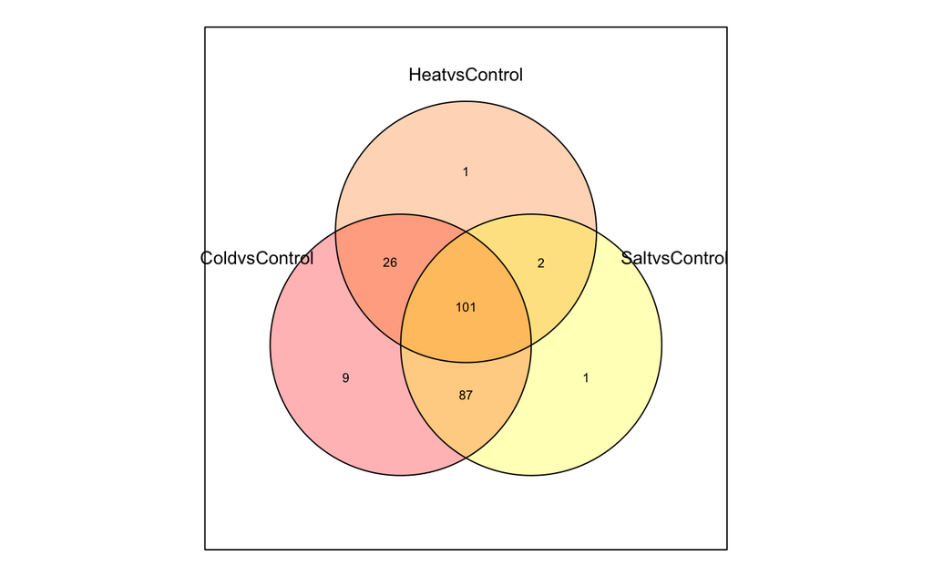

```r
G1 <-  suma2Venn(sigs$summary[, c(2:4)])# only show columns 2 to 4
```

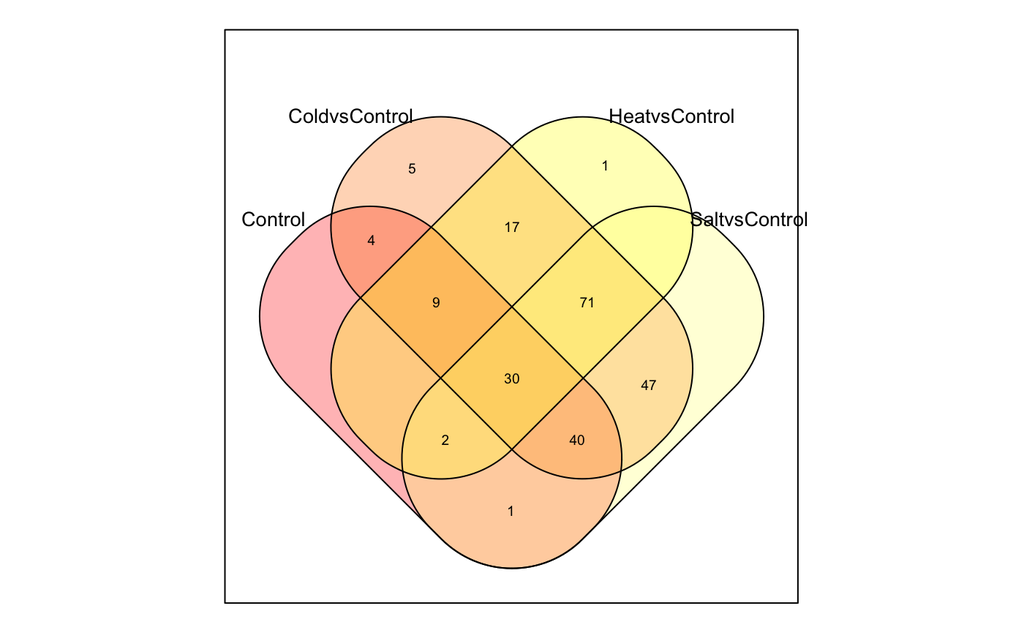

```r
G2 <-  suma2Venn(sigs$summary[, c(1:4)])# same rules
```

```r
NA
NA
```

4.2 see.genes()

```r
sigs$sig.genes$SaltvsControl$g
```

```
[1] 191
```

```r
#install.packages("nat")
# https://www.xquartz.org/
capabilities()
```

```
       jpeg         png        tiff       tcltk         X11        aqua    http/ftp
       TRUE        TRUE        TRUE        TRUE       FALSE        TRUE        TRUE
    sockets      libxml        fifo      cledit       iconv         NLS     profmem
       TRUE        TRUE        TRUE        TRUE        TRUE        TRUE        TRUE
      cairo         ICU long.double     libcurl
       TRUE        TRUE        TRUE        TRUE
```

```r
Sys.setenv("DISPLAY"=":0.0")


see.genes(sigs$sig.genes$ColdvsControl, show.fit = T, dis =design$dis,
cluster.method="hclust" ,cluster.data = 1, k = 9)
```

[output not shown]

4.3 PlotGroups()

```r
STMDE66 <- data.abiotic[rownames(data.abiotic)=="STMDE66", ] # find the row called STMDE66

# check
STMDE66 # the row we want
```

|  | Control_3H_1 | Control_3H_2 | Control_3H_3 | Control_9H_1 | Control_9H_2 | Control_9H_3 | Control_27H_1 | Control_27H_2 | Control_27H_3 | Cold_3H_1 | Cold_3H_2 | Cold_3H_3 | Cold_9H_1 | Cold_9H_2 | Cold_9H_3 | Cold_27H_1 | Cold_27H_2 | Cold_27H_3 | Heat_3H_1 | Heat_3H_2 | Heat_3H_3 | Heat_9H_1 | Heat_9H_2 | Heat_9H_3 | Heat_27H_1 | Heat_27H_2 | Heat_27H_3 | Salt_3H_1 | Salt_3H_2 | … |
| --- | --- | --- | --- | --- | --- | --- | --- | --- | --- | --- | --- | --- | --- | --- | --- | --- | --- | --- | --- | --- | --- | --- | --- | --- | --- | --- | --- | --- | --- | --- |
| STMDE66 | 0.2297699 | 0.4740975 | 0.4693072 | 0.3710106 | -0.004992029 | 0.002459839 | -0.003879953 | 0.2618276 | 0.2944903 | -1.908443 | -0.8267783 | -0.1185383 | -1.239247 | -1.215108 | -0.6401781 | -0.7247027 | -0.346255 | -0.2085104 | 0.5952455 | 0.3822309 | 0.7953431 | -0.3334077 | -0.08214904 | 0.516112 | 0.2848271 | -0.06572418 | 0.5937814 | -0.4117674 | -0.1520031 | … |

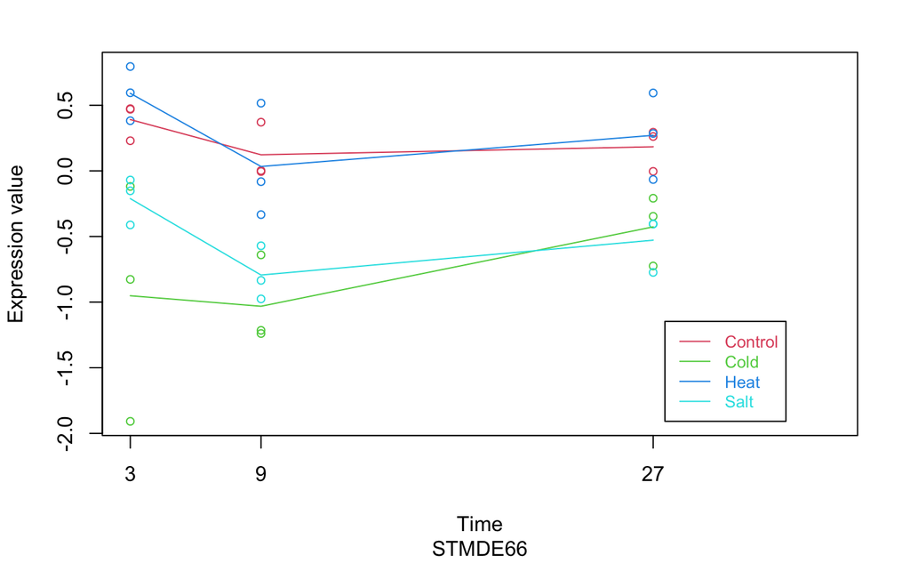

```r
PlotGroups (STMDE66, edesign = edesign.abiotic)
```

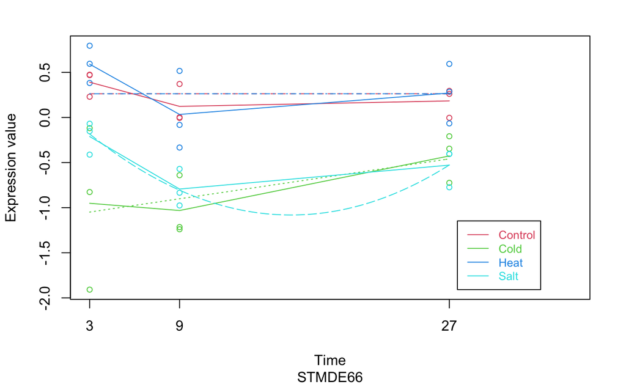

```r
PlotGroups (STMDE66, edesign = edesign.abiotic, show.fit = T, dis = design$dis,
            groups.vector = design$groups.vector)
```

```r
#  row, data, show fitting line = True, dis = regression design matrix, groups.vec
```

4.4 PlotProfiles() PlotProfiles(data, cond, main = NULL, cex.xaxis = 0.5, ylim = NULL, repvect, sub = NULL, color.mode = “rainbow”, item = NULL)

```r
# EX

# PlotProfiles(edesign.abiotic, STMDE66, main = NULL, cex.xaxis = 0.5, ylim = NULL,
#    repvect, sub = NULL, color.mode = "rainbow", item = NULL)

# We didn't assign repvect so we can't run this command successfully.
```

5.1 Single Series Time Course

```r
Time <- rep(c(1,5,10,24), each = 3) # rep replicates the values in x, each = Each element of x is repeated each times.
Replicates <- rep(c(1:4), each = 3)
Group <- rep(1,12)

ss.edesign <- cbind(Time,Replicates,Group) # columns bind
rownames(ss.edesign) <- paste("Array", c(1:12), sep = "") # paste several rows to ss.edesign names
```

```r
## Create data set
ss.GENE <- function(n, r, var11 = 0.01, var12 = 0.02, var13 = 0.02,
var14 = 0.02, a1 = 0, a2 = 0, a3 = 0, a4 = 0) {
tc.dat <- NULL
for (i in 1:n) {
gene <- c(rnorm(r, a1, var11), rnorm(r, a1, var12),
rnorm(r, a3, var13), rnorm(r, a4, var14))
tc.dat <- rbind(tc.dat, gene)
}
tc.dat }
flat <-ss.GENE(n = 85, r = 3) # flat
induc <- ss.GENE(n = 5, r = 3, a1 = 0, a2 = 0.2, a3 = 0.6, a4 = 1) # induction
sat <- ss.GENE(n = 5, r = 3, a1 = 0, a2 = 1, a3 = 1.1, a4 = 1.2) # saturation
ord <- ss.GENE(n = 5, r = 3, a1 = -0.8, a2 = -1, a3 = -1.3, a4 =-0.9) # intercept
ss.DATA <- rbind(flat, induc,sat,ord)
rownames(ss.DATA) <- paste("feature", c(1:100), sep = "")
colnames(ss.DATA) <- paste("Array", c(1:12), sep = "")
# run maSigPro
ss.example <- maSigPro(ss.DATA, ss.edesign, vars="each")
```

```
[1] "running design"
[1] "running p.vector"
[1] "fitting  gene 100 out of 100"
[1] "running T.fit"
[1] "running get.siggenes"
[1] "running see.genes  2"
[1] "running see.genes  3"
```

5.2 Common Starting Time

```r
data(edesignCT)
```

6 Next Generation-Sequencing series

counts: a logical indicating whether your data are counts. By default is FALSE for microarray treatment.

theta: θ parameter for negative.binomial family. By default θ = 10.

family: the distribution function to be used in the GLM. It must be specified as a function: gaussian(), poisson(), negative.binomial(theta)… If NULL family will be negative.binomial(theta) when counts=TRUE or gaussian() when counts=FALSE.

```r
#NBdesign is the design matrix.
data(NBdata)
data(NBdesign)
d <- make.design.matrix(NBdesign)
#If we can use maSigPro with theta = 10:
library(MASS)
NBp <- p.vector(NBdata, d, counts=TRUE)
```

```
[1] "fitting  gene 100 out of 100"
```

```r
NBt <- T.fit(NBp)
get<- get.siggenes(NBt, vars="all")
get$summary
```

```
 [1] "Gene1"  "Gene2"  "Gene3"  "Gene4"  "Gene5"  "Gene6"  "Gene7"  "Gene8"  "Gene9"
[10] "Gene10" "Gene11" "Gene13" "Gene14" "Gene17" "Gene18" "Gene19" "Gene20"
```

```r
#see.genes(get$sig.genes, k = 4)

NBp <- p.vector(NBdata, d, counts=TRUE, theta=5)
```

```
[1] "fitting  gene 100 out of 100"
```

```r
NBp <- p.vector(NBdata, d, family=poisson() )
```

```
[1] "fitting  gene 100 out of 100"
```

7 Iso-maSigPro: analysis of alternative isoform expression in time course transcriptomics experiments

```r
data(ISOdata)
data(ISOdesign)
dis <- make.design.matrix(ISOdesign)
```

7.1 IsoModel() and getDS()

IsoModel Performs a model comparison for each gene to detect genes with different trends in time course experiments and applies maSigPro to the Isoforms belonging to selected genes.

[output cut: 990 more lines]

```r
Myget <- getDS(MyIso)
```

```
[1] "51  DSG selected"
[1] "97  DETs selected"
DSG_distributed_by_number_of_DETs
 1  2  3  4  9 10
17 21  1  4  1  1
```

```r
# creates lists of significant isoforms from Differentially Spliced Genes (DSG)
# getDS(Model, vars="all", rsq=0.4)
#Model  ---   a IsoModel object
# vars ---   argument of the get.siggenes function applied to isoforms
# rsq --- cut-off level at the R-squared value for the stepwise regression fit. Only isoforms with R-squared more than rsq are selected



Myget$DSG
```

```
 [1] "Gene239"  "Gene1009" "Gene1005" "Gene800"  "Gene64"   "Gene1003" "Gene1006"
 [8] "Gene440"  "Gene63"   "Gene41"   "Gene1008" "Gene1001" "Gene500"  "Gene860"
[15] "Gene145"  "Gene793"  "Gene236"  "Gene857"  "Gene682"  "Gene107"  "Gene696"
[22] "Gene96"   "Gene409"  "Gene1002" "Gene901"  "Gene427"  "Gene684"  "Gene116"
[29] "Gene129"  "Gene852"  "Gene1007" "Gene927"  "Gene638"  "Gene850"  "Gene342"
[36] "Gene733"  "Gene1004" "Gene836"  "Gene491"  "Gene571"  "Gene183"  "Gene611"
[43] "Gene368"  "Gene463"  "Gene390"  "Gene782"  "Gene737"  "Gene995"  "Gene285"
[50] "Gene652"  "Gene595"
```

```r
Myget$DET
```

```
 [1] "Transcript122"  "Transcript125"  "Transcript147"  "Transcript150"
 [5] "Transcript269"  "Transcript270"  "Transcript416"  "Transcript422"
 [9] "Transcript423"  "Transcript445"  "Transcript526"  "Transcript528"
[13] "Transcript698"  "Transcript701"  "Transcript702"  "Transcript950"
[17] "Transcript951"  "Transcript985"  "Transcript987"  "Transcript988"
[21] "Transcript1016" "Transcript1034" "Transcript1035" "Transcript1036"
[25] "Transcript1037" "Transcript1038" "Transcript1039" "Transcript1040"
[29] "Transcript1041" "Transcript1042" "Transcript1043" "Transcript1073"
[33] "Transcript1074" "Transcript1077" "Transcript1087" "Transcript1088"
[37] "Transcript1151" "Transcript1152" "Transcript1193" "Transcript1194"
[41] "Transcript1195" "Transcript1196" "Transcript1296" "Transcript1300"
[45] "Transcript1373" "Transcript1374" "Transcript1377" "Transcript1393"
[49] "Transcript1395" "Transcript1396" "Transcript1397" "Transcript1398"
[53] "Transcript1400" "Transcript1466" "Transcript1467" "Transcript1468"
[57] "Transcript1519" "Transcript1722" "Transcript1723" "Transcript1797"
[61] "Transcript1836" "Transcript1876" "Transcript1899" "Transcript1900"
[65] "Transcript2063" "Transcript2067" "Transcript2268" "Transcript2298"
[69] "Transcript2322" "Transcript2323" "Transcript2324" "Transcript2326"
[73] "Transcript2330" "Transcript2331" "Transcript2332" "Transcript2333"
[77] "Transcript2334" "Transcript2341" "Transcript2342" "Transcript2405"
[81] "Transcript2413" "Transcript2414" "Transcript2416" "Transcript2417"
[85] "Transcript2460" "Transcript2461" "Transcript2462" "Transcript2463"
[89] "Transcript2472" "Transcript2482" "Transcript2483" "Transcript2485"
[93] "Transcript2486" "Transcript2633" "Transcript2634" "Transcript2731"
[97] "Transcript2732"
```

```r
Myget$List0
```

```
[1] "Gene857" "Gene491" "Gene611" "Gene995" "Gene285" "Gene652"
```

7.2 Clustering strategy: seeDS() and tableDS()

```r
table <- tableDS(see)
```

[output not shown]

7.3 PodiumChange()

```r
PC<-PodiumChange(Myget, only.sig.iso=TRUE, comparison="specific",
group.name="Group2", time.points=c(18,24))
PC$L
```

```
[1] "Gene239"  "Gene1008" "Gene1005"
```

7.4 IsoPlot()

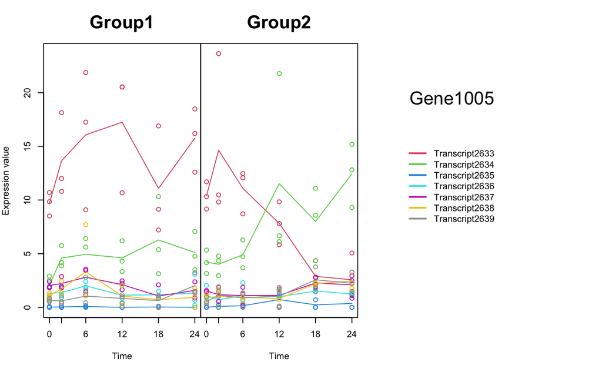

```r
IsoPlot(Myget,"Gene1005",only.sig.iso=FALSE,cex.main=2,cex.legend=1)
```